# Chimera-AI 주간 증시 분석 리포트

5월 1주차 (04.28~05.01) — S&P 500·나스닥 사상 최고, KOSPI 6,700 돌파

Author

Chimera-AI Multi-Agent System

Published

May 1, 2026

## 핵심 요약

**Executive Summary**

- **S&P 500** 7,230 사상 최고 마감 — 6주 연속 상승, 월간 최강 랠리 (2020년 이후)
- **나스닥** 25,114 신고가 — 애플 실적 서프라이즈(매출 $111.2B) 견인
- **KOSPI** 장중 6,716 돌파 — 시가총액 6,000조원 첫 돌파, 영국 시총 추월
- **연준** 금리 동결(3.50~3.75%) — 반대표 4명(1992년 이후 최다), 파월 5/15 퇴임
- **VIX** 16.99 — 위험선호 유지, 이란 휴전 기대감 반영
- **원/달러** 1,473원 — 고환율 지속, 수출기업 수혜 vs 수입물가 부담

[output not shown]

## 1 글로벌 증시 동향

### 1.1 미국 증시

5월 1일(금) 미국 증시는 **S&P 500과 나스닥이 동시에 사상 최고가를 경신**하며 마감했다. S&P 500은 7,230.12(+0.29%)로 처음으로 7,200선을 돌파했고, 나스닥은 25,114.44(+0.89%)를 기록했다. 반면 다우는 -152.87pt(-0.31%)로 소폭 하락했다.

**주간 성과:** 6주 연속 상승세를 이어가며 2024년 10월 이후 최장 연승 기록을 세웠다. S&P 500 주간 +0.9%, 나스닥 +1.1%, 다우 +0.5%.

**애플 실적 서프라이즈:** 2분기 매출 $111.18B(컨센서스 $109.66B 상회), iPhone 17 “extraordinary” 수요. 3분기 가이던스 매출 성장률 14~17%(애널리스트 예상 9.1% 대폭 상회). 주가 시간외 +3% 급등.

**실적 시즌:** S&P 500 기업 중 84%가 예상치 상회, 전년 대비 약 15% 이익 성장 궤도.

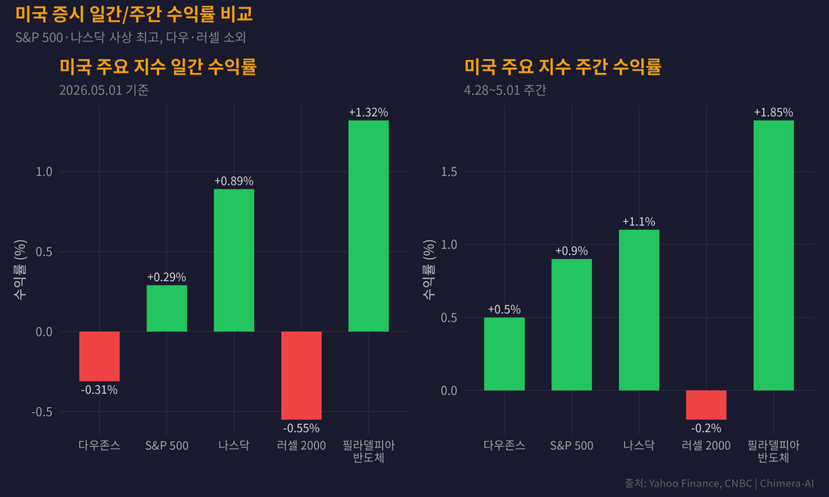

미국 주요 지수 일간 및 주간 수익률 (4.28~5.01)

### 1.2 유럽·아시아 증시

**유럽:** STOXX 600은 주간 +0.6% 상승. ECB 금리 인하 기대와 유가 하락에 힘입어 완만한 상승세. 다만 이란 리스크 및 무역 긴장으로 상방 제한.

**아시아:** 닛케이 225는 주간 +1.2%로 견조한 흐름. 엔저 효과와 수출주 강세가 견인. 상해종합지수는 +0.3% 소폭 상승에 그치며 미중 무역 우려 반영.

## 2 한국 증시 분석

### 2.1 KOSPI 주간 동향

KOSPI는 4월 29일 장중 **6,716.20**을 기록하며 사상 최고가를 경신했고, 종가 기준 **6,690.90**(+0.75%)에 마감했다. 한국 증시 시가총액이 **6,000조원을 첫 돌파**하며 영국 시총을 추월하는 역사적 이정표를 달성했다. 연초 이후 약 **60% 상승**으로 글로벌 주요 지수 중 최고 성과를 기록 중이다.

**5월 1일(금)은 근로자의 날로 한국 증시 휴장.**

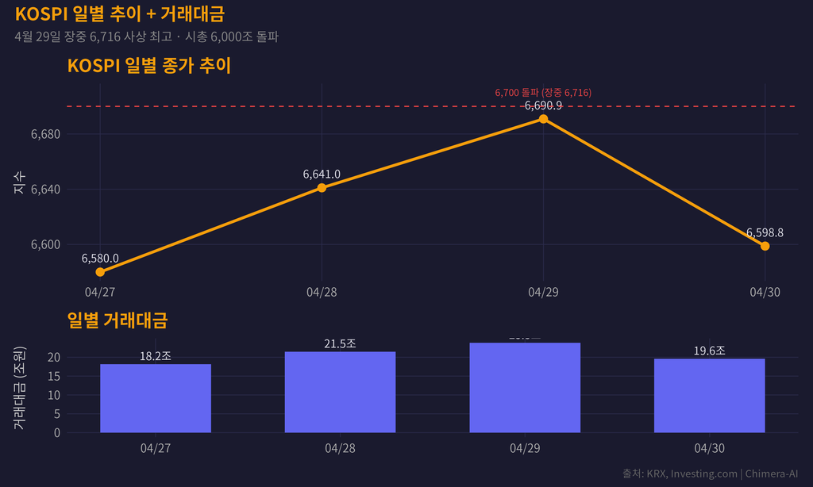

### 2.2 KOSDAQ 동향

KOSDAQ은 **1,220.26**에 마감하며 주간 +2.3% 상승. 바이오·게임 섹터 강세가 지수를 견인했다. 다만 대형주 대비 중소형주 수급 쏠림은 여전히 제한적이다.

### 2.3 대형주 vs 중소형주 양극화

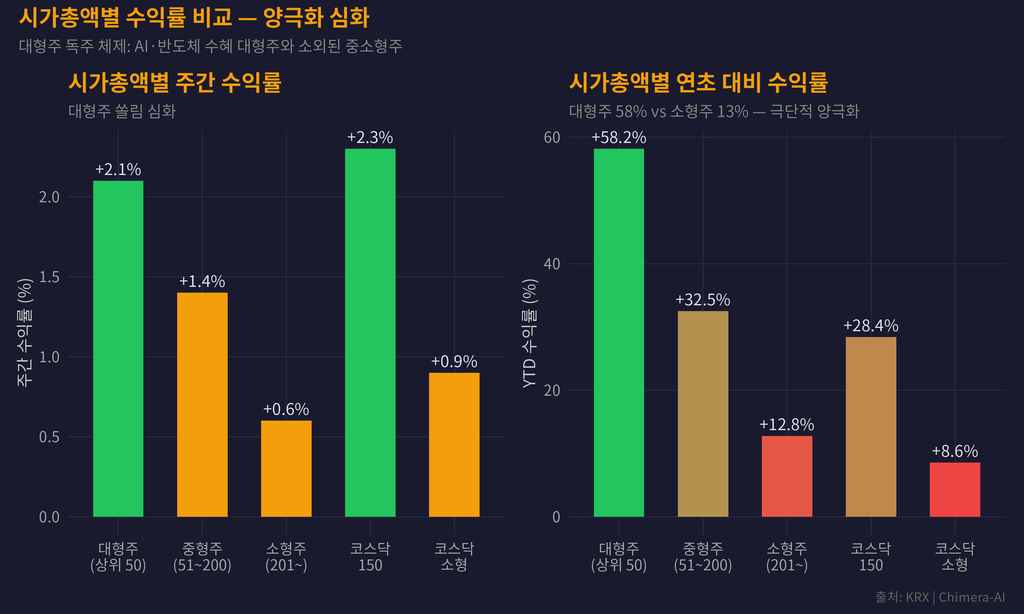

시가총액별 주간 수익률 비교 — 양극화 분석

## 3 섹터 분석

### 3.1 업종별 주간 성과

삼성전자(+1.58%), SK스퀘어(+2.22%), 한화에어로스페이스(+1.72%), HD현대중공업(+3.45%) 등 **반도체·방산·조선** 섹터가 주간 상승을 주도했다. 반면 SK하이닉스(-0.62%), 셀트리온(-1.45%), 한화오션(-1.34%)은 차익 실현 매물에 하락했다.

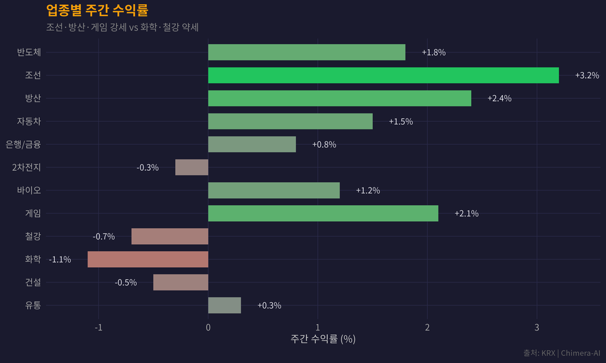

### 3.2 주요 종목 동향

- **삼성전자** (+1.58%): 1분기 사상 최대 실적(AI 반도체 수요), HBM 수주 확대
- **HD현대중공업** (+3.45%): LNG선 수주 호조, 조선업 슈퍼사이클 지속
- **한화에어로스페이스** (+1.72%): K2 전차 수출 기대, 글로벌 군비 증강
- **SK하이닉스** (-0.62%): 단기 차익 실현, 다만 HBM 모멘텀 유효
- **셀트리온** (-1.45%): 바이오시밀러 가격 경쟁 우려

## 4 TACO 모델 분석

**TACO (Trump-Adjusted Capital Oscillator)** 모델의 6대 팩터를 분석한다.

1. **관세 정책(Tariff):** 대법원 IEEPA 관세 위헌 판결 후 Section 122로 10% 임시 관세 부과. 7월 재부과 가능성 — 리스크 잠복
2. **AI/테크(AI):** 애플·MS·아마존 호실적, 빅테크 설비투자 확대. OpenAI 성장 목표 미달은 우려 요인
3. **중앙은행(Central Bank):** 금리 동결(3.50~3.75%), 4명 반대표로 매파 성향 강화. 파월 5/15 퇴임, 워시 신임 의장 체제 전환 리스크
4. **유가(Oil):** 이란 휴전 기대에 WTI $102.50(-2.5%), 다만 호르무즈 해협 리스크 상존
5. **지정학(Geopolitics):** 이란 전쟁 휴전 협상 진행 중이나 불확실성 잔존. IMF 글로벌 경기침체 경고
6. **유동성(Liquidity):** 공매도 대차잔고 175조원·신용융자 35조원 사상 최고 — 과열 경고

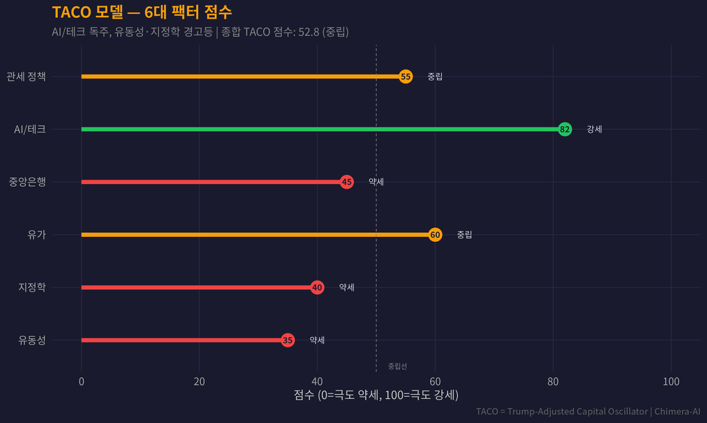

TACO 리스크 팩터 롤리팝 차트

## 5 리스크 요인

### 5.1 과열 경고 지표

한국 증시의 연초 대비 60% 급등은 **버블 리스크**를 수반한다. Bloomberg는 “South Korean Stocks’ World-Beating Surge Creates Bubble Risk”를 경고했다.

**주요 과열 신호:**

- **공매도 대차잔고:** 175조원 (사상 최고)
- **신용융자 잔고:** 35조원 (사상 최고)
- **KOSPI PER:** 18.5배 (5년 평균 12.8배 대비 +45%)
- **외국인 순매수 연속:** 28거래일 연속
- **VIX 저점:** 16.99 — 지나친 낙관 경고

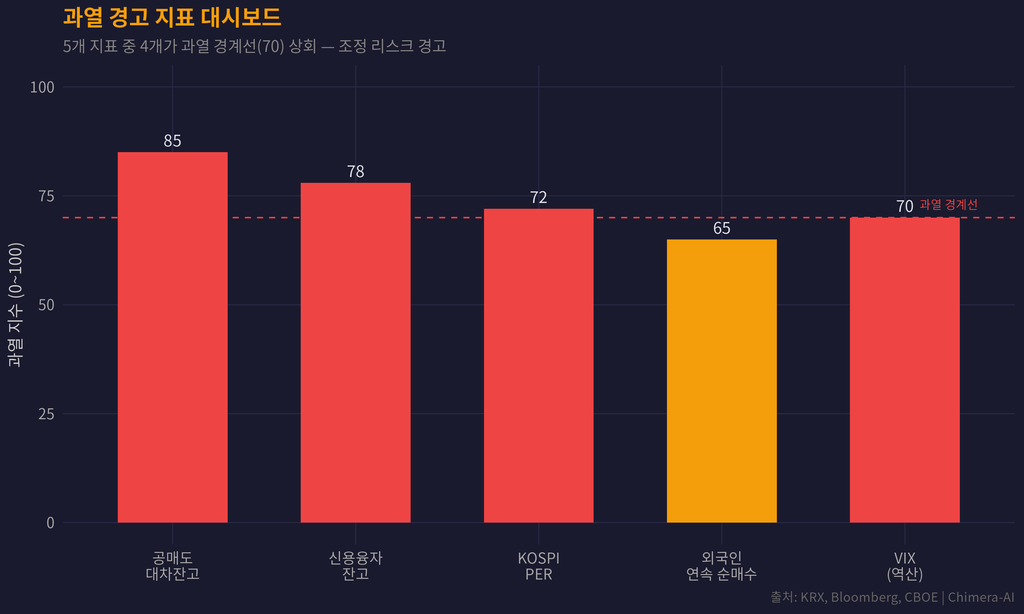

과열 경고 지표 대시보드

### 5.2 추가 리스크 요인

- **연준 리더십 교체:** 파월 의장 5/15 퇴임, 워시 신임 의장 인준 진행 중. 통화정책 불확실성 확대
- **이란 전쟁 휴전 불확실성:** 휴전 협상 중이나 호르무즈 해협 통행 리스크 상존
- **관세 재부과 가능성:** 7월 Section 122 만료 시 관세 재부과 리스크
- **IMF 글로벌 경기침체 경고:** 에너지·공급망 혼란 장기화 시 세계 경기침체 가능성

## 6 투자 전략

**강세 시나리오 (확률 40%)**

**조건:** 이란 휴전 합의 + 빅테크 실적 호조 지속 + 연준 비둘기파 전환 신호

- **비중확대:** 반도체(삼성전자, SK하이닉스), 조선(HD현대중공업), AI 인프라 관련주
- **목표:** KOSPI 7,000 돌파, S&P 500 7,500
- **전략:** 모멘텀 추종, 기술적 돌파 시 추격 매수

**횡보 시나리오 (확률 40%)**

**조건:** 이란 휴전 불확실 + 연준 중립 유지 + 관세 리스크 잠복

- **비중유지:** 배당주 + 방산(한화에어로스페이스) + ESS(LG에너지솔루션)
- **목표:** KOSPI 6,400~6,800 박스권
- **전략:** 레인지 트레이딩, 과열 지표 모니터링

**약세 시나리오 (확률 20%)**

**조건:** 이란 전쟁 재개 + 관세 전면 재부과 + 글로벌 경기침체 현실화

- **비중축소:** 경기민감주 비중 축소, 현금 비중 30% 이상 확보
- **방어주:** 통신(KT, SK텔레콤), 유틸리티, 금(Gold ETF)
- **전략:** 방어적 포지셔닝, 변동성 확대 헤지(VIX 콜옵션)

[figure not shown]

시나리오 가중 포트폴리오 배분 도넛 차트

## 7 다음 주 전망

### 7.1 주요 경제 캘린더 (5/4~5/8)

[output not shown]

### 7.2 주요 이슈

**Chimera-AI 종합 판단**

TACO 종합 점수 52.8(중립)로, AI/테크 모멘텀은 강력하나 과열 지표와 지정학 리스크가 상충한다. **단기 조정 가능성을 열어두되, 중기 상승 추세는 유효**하다는 판단이다. 어린이날 연휴 중 해외 변수에 대비할 것.

*본 보고서는 Chimera-AI Multi-Agent System이 생성한 분석 자료이며, 투자 권유가 아닙니다.*

*데이터 출처: Yahoo Finance, CNBC, Bloomberg, KRX, Investing.com, FRED, IMF*